# Project 1: Wrangling, Exploration, Visualization

SDS322E

## Data Wrangling, Exploration, Visualization

### Sarah Isaack sji259

#### Introduction

```r
# read your datasets in here, e.g., with read_csv()
library(readr)
state_candy <- read_csv("/stor/home/sji259/project1/state_candy.csv")
state_candy
```

```
## # A tibble: 51 x 3
##    State `Top Candy`                Pounds
##    <chr> <chr>                       <dbl>
##  1 AL    Starburst                  109287
##  2 AK    Sour Patch Kids              4782
##  3 AZ    Hot Tamales                770928
##  4 AR    Jolly Ranchers             211337
##  5 CA    Reese's Peanut Butter cup 1209299
##  6 CO    Hershey's Kisses           119050
##  7 CT    Almond Joy                   2873
##  8 DE    Skittles original           19827
##  9 FL    Reese's Peanut Butter cup  578292
## 10 GA    Swedish Fish               136319
## # … with 41 more rows
```

```r
library(fivethirtyeight)
candy_rankings <- candy_rankings
```

#### Tidying: Reshaping

```r
library(dplyr)
library(tidyr)
# My data was already tidy, so I will be untidying and
# retidying it#
state_candy_wide <- state_candy %>% pivot_wider(names_from = "Top Candy",
    values_from = "Pounds")
state_candy_wide %>% pivot_longer(2:20, names_to = "Top Candy",
    values_to = "Pounds") %>% na.omit
```

```
## # A tibble: 51 x 3
##    State `Top Candy`                Pounds
##    <chr> <chr>                       <dbl>
##  1 AL    Starburst                  109287
##  2 AK    Sour Patch Kids              4782
##  3 AZ    Hot Tamales                770928
##  4 AR    Jolly Ranchers             211337
##  5 CA    Reese's Peanut Butter cup 1209299
##  6 CO    Hershey's Kisses           119050
##  7 CT    Almond Joy                   2873
##  8 DE    Skittles original           19827
##  9 FL    Reese's Peanut Butter cup  578292
## 10 GA    Swedish Fish               136319
## # … with 41 more rows
```

```r
candy_rank_wide <- candy_rankings %>% pivot_wider(names_from = "competitorname",
    values_from = "winpercent")
candy_rank_wide %>% pivot_longer("100 Grand":"Whoppers", names_to = "competitorname",
    values_to = "winpercent") %>% na.omit
```

```
## # A tibble: 85 x 13
##    chocolate fruity caramel peanutyalmondy nougat crispedricewafer hard  bar
##    <lgl>     <lgl>  <lgl>   <lgl>          <lgl>  <lgl>            <lgl> <lgl>
##  1 TRUE      FALSE  TRUE    FALSE          FALSE  TRUE             FALSE TRUE
##  2 TRUE      FALSE  FALSE   FALSE          TRUE   FALSE            FALSE TRUE
##  3 TRUE      FALSE  FALSE   FALSE          TRUE   FALSE            FALSE TRUE
##  4 FALSE     FALSE  FALSE   FALSE          FALSE  FALSE            FALSE FALSE
##  5 FALSE     FALSE  FALSE   FALSE          FALSE  FALSE            FALSE FALSE
##  6 FALSE     TRUE   FALSE   FALSE          FALSE  FALSE            FALSE FALSE
##  7 TRUE      FALSE  FALSE   TRUE           FALSE  FALSE            FALSE TRUE
##  8 TRUE      FALSE  TRUE    TRUE           TRUE   FALSE            FALSE TRUE
##  9 FALSE     FALSE  FALSE   TRUE           FALSE  FALSE            FALSE FALSE
## 10 FALSE     FALSE  FALSE   FALSE          FALSE  FALSE            FALSE FALSE
## # … with 75 more rows, and 5 more variables: pluribus <lgl>,
## #   sugarpercent <dbl>, pricepercent <dbl>, competitorname <chr>,
## #   winpercent <dbl>
```

I did consider making the table longer so that all of the different flavor columns would just be in one column, however since one candy can have many different flavors, this made the resulting dataset incredibly long and cumbersome to work with. It also made it harder to see the relationships between the states and candies, which is what I am most interested in.

#### Joining/Merging

```r
joined_candy <- right_join(candy_rankings, state_candy, by = c(competitorname = "Top Candy"))
glimpse(joined_candy)
```

```
## Rows: 51
## Columns: 15
## $ competitorname   <chr> "3 Musketeers", "Almond Joy", "Hershey's Kisses", "H…
## $ chocolate        <lgl> TRUE, TRUE, TRUE, TRUE, TRUE, FALSE, TRUE, TRUE, TRU…
## $ fruity           <lgl> FALSE, FALSE, FALSE, FALSE, FALSE, TRUE, FALSE, FALS…
## $ caramel          <lgl> FALSE, FALSE, FALSE, FALSE, FALSE, FALSE, FALSE, FAL…
## $ peanutyalmondy   <lgl> FALSE, TRUE, FALSE, FALSE, FALSE, FALSE, FALSE, FALS…
## $ nougat           <lgl> TRUE, FALSE, FALSE, FALSE, FALSE, FALSE, FALSE, FALS…
## $ crispedricewafer <lgl> FALSE, FALSE, FALSE, FALSE, FALSE, FALSE, FALSE, FAL…
## $ hard             <lgl> FALSE, FALSE, FALSE, FALSE, FALSE, TRUE, FALSE, FALS…
## $ bar              <lgl> TRUE, TRUE, FALSE, FALSE, FALSE, FALSE, FALSE, FALSE…
## $ pluribus         <lgl> FALSE, FALSE, TRUE, TRUE, TRUE, FALSE, TRUE, TRUE, T…
## $ sugarpercent     <dbl> 0.604, 0.465, 0.127, 0.127, 0.127, 0.046, 0.825, 0.8…
## $ pricepercent     <dbl> 0.511, 0.767, 0.093, 0.093, 0.093, 0.104, 0.651, 0.6…
## $ winpercent       <dbl> 67.60294, 50.34755, 55.37545, 55.37545, 55.37545, 39…
## $ State            <chr> "MS", "CT", "CO", "MD", "NV", "LA", "IA", "NH", "NJ"…
## $ Pounds           <dbl> 92736, 2873, 119050, 34827, 293248, 115789, 64031, 6…
```

```r
glimpse(candy_rankings)
```

```
## Rows: 85
## Columns: 13
## $ competitorname   <chr> "100 Grand", "3 Musketeers", "One dime", "One quarte…
## $ chocolate        <lgl> TRUE, TRUE, FALSE, FALSE, FALSE, TRUE, TRUE, FALSE, …
## $ fruity           <lgl> FALSE, FALSE, FALSE, FALSE, TRUE, FALSE, FALSE, FALS…
## $ caramel          <lgl> TRUE, FALSE, FALSE, FALSE, FALSE, FALSE, TRUE, FALSE…
## $ peanutyalmondy   <lgl> FALSE, FALSE, FALSE, FALSE, FALSE, TRUE, TRUE, TRUE,…
## $ nougat           <lgl> FALSE, TRUE, FALSE, FALSE, FALSE, FALSE, TRUE, FALSE…
## $ crispedricewafer <lgl> TRUE, FALSE, FALSE, FALSE, FALSE, FALSE, FALSE, FALS…
## $ hard             <lgl> FALSE, FALSE, FALSE, FALSE, FALSE, FALSE, FALSE, FAL…
## $ bar              <lgl> TRUE, TRUE, FALSE, FALSE, FALSE, TRUE, TRUE, FALSE, …
## $ pluribus         <lgl> FALSE, FALSE, FALSE, FALSE, FALSE, FALSE, FALSE, TRU…
## $ sugarpercent     <dbl> 0.732, 0.604, 0.011, 0.011, 0.906, 0.465, 0.604, 0.3…
## $ pricepercent     <dbl> 0.860, 0.511, 0.116, 0.511, 0.511, 0.767, 0.767, 0.5…
## $ winpercent       <dbl> 66.97173, 67.60294, 32.26109, 46.11650, 52.34146, 50…
```

```r
glimpse(state_candy)
```

```
## Rows: 51
## Columns: 3
## $ State       <chr> "AL", "AK", "AZ", "AR", "CA", "CO", "CT", "DE", "FL", "GA…
## $ `Top Candy` <chr> "Starburst", "Sour Patch Kids", "Hot Tamales", "Jolly Ran…
## $ Pounds      <dbl> 109287, 4782, 770928, 211337, 1209299, 119050, 2873, 1982…
```

```r
joined_candy %>% summarize(sum(is.na(chocolate)))
```

```
## # A tibble: 1 x 1
##   `sum(is.na(chocolate))`
##                     <int>
## 1                      12
```

```r
anti_join(state_candy, candy_rankings, by = c(`Top Candy` = "competitorname"))
```

```
## # A tibble: 12 x 3
##    State `Top Candy`         Pounds
##    <chr> <chr>                <dbl>
##  1 AZ    Hot Tamales         770928
##  2 AR    Jolly Ranchers      211337
##  3 HI    Hershey's Mini Bars  25827
##  4 MT    Dubble Bubble Gum    28736
##  5 NM    Jolly Ranchers       75447
##  6 ND    Hot Tamales          58726
##  7 OH    Blow Pops           157827
##  8 PA    Hershey's Mini Bars 239081
##  9 SC    Butterfinger        112879
## 10 VA    Hot Tamales         155272
## 11 WV    Hershey's Mini Bars  35930
## 12 WI    Butterfinger        103827
```

```r
anti_join(candy_rankings, state_candy, by = c(competitorname = "Top Candy"))
```

```
## # A tibble: 72 x 13
##    competitorname chocolate fruity caramel peanutyalmondy nougat
##    <chr>          <lgl>     <lgl>  <lgl>   <lgl>          <lgl>
##  1 100 Grand      TRUE      FALSE  TRUE    FALSE          FALSE
##  2 One dime       FALSE     FALSE  FALSE   FALSE          FALSE
##  3 One quarter    FALSE     FALSE  FALSE   FALSE          FALSE
##  4 Air Heads      FALSE     TRUE   FALSE   FALSE          FALSE
##  5 Baby Ruth      TRUE      FALSE  TRUE    TRUE           TRUE
##  6 Boston Baked … FALSE     FALSE  FALSE   TRUE           FALSE
##  7 Candy Corn     FALSE     FALSE  FALSE   FALSE          FALSE
##  8 Caramel Apple… FALSE     TRUE   TRUE    FALSE          FALSE
##  9 Charleston Ch… TRUE      FALSE  FALSE   FALSE          TRUE
## 10 Chewey Lemonh… FALSE     TRUE   FALSE   FALSE          FALSE
## # … with 62 more rows, and 7 more variables: crispedricewafer <lgl>,
## #   hard <lgl>, bar <lgl>, pluribus <lgl>, sugarpercent <dbl>,
## #   pricepercent <dbl>, winpercent <dbl>
```

#### Wrangling

```r
joined_candy %>% mutate(Kilograms = (Pounds * 0.453592))
```

```
## # A tibble: 51 x 16
##    competitorname chocolate fruity caramel peanutyalmondy nougat
##    <chr>          <lgl>     <lgl>  <lgl>   <lgl>          <lgl>
##  1 3 Musketeers   TRUE      FALSE  FALSE   FALSE          TRUE
##  2 Almond Joy     TRUE      FALSE  FALSE   TRUE           FALSE
##  3 Hershey's Kis… TRUE      FALSE  FALSE   FALSE          FALSE
##  4 Hershey's Kis… TRUE      FALSE  FALSE   FALSE          FALSE
##  5 Hershey's Kis… TRUE      FALSE  FALSE   FALSE          FALSE
##  6 Lemonhead      FALSE     TRUE   FALSE   FALSE          FALSE
##  7 M&M's          TRUE      FALSE  FALSE   FALSE          FALSE
##  8 M&M's          TRUE      FALSE  FALSE   FALSE          FALSE
##  9 M&M's          TRUE      FALSE  FALSE   FALSE          FALSE
## 10 M&M's          TRUE      FALSE  FALSE   FALSE          FALSE
## # … with 41 more rows, and 10 more variables: crispedricewafer <lgl>,
## #   hard <lgl>, bar <lgl>, pluribus <lgl>, sugarpercent <dbl>,
## #   pricepercent <dbl>, winpercent <dbl>, State <chr>, Pounds <dbl>,
## #   Kilograms <dbl>
```

When using mutate, I created a variable called Kilograms which converts the pounds variable to show the amount of the specific Halloween candy bought in kilograms for the year of the study.

```r
joined_candy %>% group_by(competitorname) %>% summarize(count = n_distinct(State)) %>%
    arrange(desc(count))
```

```
## # A tibble: 19 x 2
##    competitorname            count
##    <chr>                     <int>
##  1 Reese's Peanut Butter cup     6
##  2 Sour Patch Kids               6
##  3 Starburst                     6
##  4 M&M's                         5
##  5 Tootsie Pop                   4
##  6 Hershey's Kisses              3
##  7 Hershey's Mini Bars           3
##  8 Hot Tamales                   3
##  9 Skittles original             3
## 10 Butterfinger                  2
## 11 Jolly Ranchers                2
## 12 3 Musketeers                  1
## 13 Almond Joy                    1
## 14 Blow Pops                     1
## 15 Dubble Bubble Gum             1
## 16 Lemonhead                     1
## 17 Milky Way                     1
## 18 Swedish Fish                  1
## 19 Twix                          1
```

In order to visualize which Halloween candies were popular in the most states, I first used group_by to group all of the candies together, then I used summarize to count up the distinct states that each candy was the favorite of. Lastly, I arranged this count in descending order so that the most popular candies could be viewed. From this I gathered that Reese’s cups, Sour Patch Kids, and Starburst are tied for most popular as they all are the favorite in 6 different states.

```r
joined_candy %>% filter(Pounds == max(Pounds)) %>% select("competitorname",
    "winpercent", "State", "Pounds")
```

```
## # A tibble: 1 x 4
##   competitorname            winpercent State  Pounds
##   <chr>                          <dbl> <chr>   <dbl>
## 1 Reese's Peanut Butter cup       84.2 CA    1209299
```

```r
joined_candy %>% arrange(desc(winpercent))
```

```
## # A tibble: 51 x 15
##    competitorname chocolate fruity caramel peanutyalmondy nougat
##    <chr>          <lgl>     <lgl>  <lgl>   <lgl>          <lgl>
##  1 Reese's Peanu… TRUE      FALSE  FALSE   TRUE           FALSE
##  2 Reese's Peanu… TRUE      FALSE  FALSE   TRUE           FALSE
##  3 Reese's Peanu… TRUE      FALSE  FALSE   TRUE           FALSE
##  4 Reese's Peanu… TRUE      FALSE  FALSE   TRUE           FALSE
##  5 Reese's Peanu… TRUE      FALSE  FALSE   TRUE           FALSE
##  6 Reese's Peanu… TRUE      FALSE  FALSE   TRUE           FALSE
##  7 Twix           TRUE      FALSE  TRUE    FALSE          FALSE
##  8 Milky Way      TRUE      FALSE  TRUE    FALSE          TRUE
##  9 3 Musketeers   TRUE      FALSE  FALSE   FALSE          TRUE
## 10 Starburst      FALSE     TRUE   FALSE   FALSE          FALSE
## # … with 41 more rows, and 9 more variables: crispedricewafer <lgl>,
## #   hard <lgl>, bar <lgl>, pluribus <lgl>, sugarpercent <dbl>,
## #   pricepercent <dbl>, winpercent <dbl>, State <chr>, Pounds <dbl>
```

I was curious to know which candy had been purchased the most by weight. To figure this out, I filtered the joined_candy data so that the row with the highest Pound variable was chosen, then I selected the columns that I was interested in seeing, in this case, the columns for the candy name, the win percentage that the candy has won when it went up against other candies, the state that bought the pounds of candy, and the number of pounds that were bought. I learned that California bought the most candy, which happened to be Reese’s Peanut Butter Cups. It also worked out that this candy had the highest win percentage, which I found by arranging the data in a descending order according to win percentage.

```r
library(knitr)
library(stringr)
table1 <- joined_candy %>% summarize(mean_sugar = mean(sugarpercent,
    na.rm = T), sugar_sd = sd(sugarpercent, na.rm = T), sugar_var = var(sugarpercent,
    na.rm = T), n())
table1 %>% kable(digits = 3, align = "c", col.names = str_to_title(names(.)))
```

| Mean_sugar | Sugar_sd | Sugar_var | N() |
| --- | --- | --- | --- |
| 0.468 | 0.321 | 0.103 | 51 |

The numeric variable sugarpercent shows the percentile of sugar that a certain candy falls under within the data set. After using this variable to calculate some summary statistics, it is shown that the average of all the candies sugar content falls around the 47th percentile when rounded. The standard deviation in all the candies is 0.3207757 percentiles, and the variance between the candies is pretty low at 0.102897. Lastly, there are 51 different rows of candies for this variable.

```r
library(knitr)
library(stringr)
table2 <- joined_candy %>% summarize(mean_price = mean(pricepercent,
    na.rm = T), price_sd = sd(pricepercent, na.rm = T), price_var = var(pricepercent,
    na.rm = T), n())
table2 %>% kable(digits = 3, align = "c", col.names = str_to_title(names(.)))
```

| Mean_price | Price_sd | Price_var | N() |
| --- | --- | --- | --- |
| 0.387 | 0.254 | 0.064 | 51 |

The numeric variable price percent is a record of the price percentile per unit that the candy falls into in comparison with the other candies in the dataset. In order to compare this percentile calculation to the other percentile variable sugarpercent, I calculated the same summary statistics for both variables. When compared to sugarpercent, pricepercent has on average a lower percentile, a lower standard deviation, and a lower variance. Likewise with sugarpercent, there are still 51 observations.

```r
library(knitr)
library(stringr)
table3 <- joined_candy %>% summarize(win_mean = mean(winpercent,
    na.rm = T))
table3 %>% kable(digits = 3, align = "c", col.names = str_to_title(names(.)))
```

| Win_mean |
| --- |
| 64.548 |

```r
table4 <- joined_candy %>% group_by(chocolate) %>% summarize(winmean = mean(winpercent,
    na.rm = T), win_min = min(winpercent, na.rm = T), win_max = (max(winpercent,
    na.rm = T)))
table4 %>% kable(digits = 3, align = "c", col.names = str_to_title(names(.)))
```

| Chocolate | Winmean | Win_min | Win_max |
| --- | --- | --- | --- |
| FALSE | 61.451 | 39.141 | 67.038 |
| TRUE | 66.941 | 48.983 | 84.180 |
| NA | NaN | Inf | -Inf |

The next numeric variable I had was winpercent, which is the percentage that the candy in question won against 269,000 matchups with other candies. First, I wanted to see just the overall average of wins throughout all the candy in the data set, which was 64.548%. Next, I wanted to see how just the chocolate group performed, and if they won more or less often than the entire group. After grouping by chocolate, the winning average for candies that contained chocolate was 66.94112% while candies without chocolate won an average of 61.45102% of the time. I also found the minimum and maximum of the candies that had chocolate and those that don’t, which shows that chocolate-containing candies might be more popular.

```r
library(knitr)
library(stringr)
table5 <- joined_candy %>% summarize(avg_pound = mean(Pounds,
    na.rm = T), n_distinct(Pounds), max_pound = max(Pounds, na.rm = T),
    min_pound = min(Pounds, na.rm = T))
table5 %>% kable(digits = 3, align = "c", col.names = str_to_title(names(.)))
```

| Avg_pound | N_distinct(Pounds) | Max_pound | Min_pound |
| --- | --- | --- | --- |
| 159803.5 | 51 | 1209299 | 2873 |

```r
table6 <- joined_candy %>% group_by(fruity, chocolate) %>% summarize(mean_weight = mean(Pounds,
    na.rm = T))
table6 %>% kable(digits = 3, align = "c", col.names = str_to_title(names(.)))
```

| Fruity | Chocolate | Mean_weight |
| --- | --- | --- |
| FALSE | TRUE | 175840.3 |
| TRUE | FALSE | 128243.8 |
| TRUE | TRUE | 207222.0 |
| NA | NA | 164651.4 |

The last numeric variable is Pounds, which is the weight in pounds that each state bought of their favorite candy. First, I wanted to just see some characteristics about this variable. I found that the mean pounds of candy bought overall was 159,803.5 lbs with a max of 1,209,299 lbs and a min of 2873 lbs. Next, I wanted to see if the type of candy had any effect on the number of pounds bought, so I grouped by fruity type and chocolate type to see any differences. After grouping them the data showed that when fruity and chocolate type flavors are in the same candy, more pounds of the candy are sold followed by only chocolate, followed by only fruity.

```r
library(knitr)
library(stringr)
table7 <- joined_candy %>% group_by(competitorname) %>% count
table7 %>% kable(digits = 3, align = "c", col.names = str_to_title(names(.)))
```

| Competitorname | N |
| --- | --- |
| 3 Musketeers | 1 |
| Almond Joy | 1 |
| Blow Pops | 1 |
| Butterfinger | 2 |
| Dubble Bubble Gum | 1 |
| Hershey’s Kisses | 3 |
| Hershey’s Mini Bars | 3 |
| Hot Tamales | 3 |
| Jolly Ranchers | 2 |
| Lemonhead | 1 |
| M&M’s | 5 |
| Milky Way | 1 |
| Reese’s Peanut Butter cup | 6 |
| Skittles original | 3 |
| Sour Patch Kids | 6 |
| Starburst | 6 |
| Swedish Fish | 1 |
| Tootsie Pop | 4 |
| Twix | 1 |

```r
joined_candy %>% group_by(State) %>% count
```

```
## # A tibble: 51 x 2
## # Groups:   State [51]
##    State     n
##    <chr> <int>
##  1 AK        1
##  2 AL        1
##  3 AR        1
##  4 AZ        1
##  5 CA        1
##  6 CO        1
##  7 CT        1
##  8 DC        1
##  9 DE        1
## 10 FL        1
## # … with 41 more rows
```

There are only two character type variables in the joined dataset, competitorname and state. For competitor name, all of the candy counts are seen above for the 19 different candies, and there are no NAs present in this column. For state, all US states as well as Washington DC are included and each are only used once in the dataset. This column also does not have any NAs.

#### Visualizing

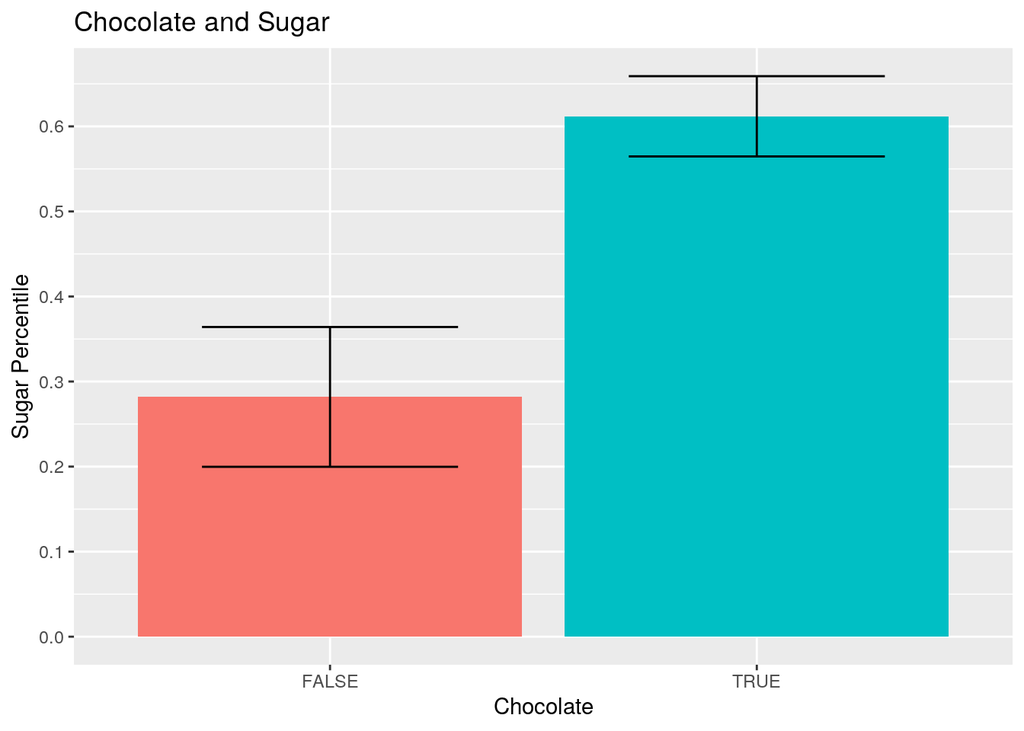

```r
library(ggplot2)
joined_candy %>% group_by(chocolate) %>% na.omit() %>% ggplot(aes(x = chocolate,
    fill = chocolate)) + geom_bar(aes(y = sugarpercent), stat = "summary",
    fun = mean) + geom_errorbar(aes(y = sugarpercent), stat = "summary",
    fun.data = mean_se, width = 0.6) + xlab("Chocolate") + ylab("Sugar Percentile") +
    ggtitle("Chocolate and Sugar") + theme(legend.position = "none") +
    scale_y_continuous(breaks = seq(0, 0.8, 0.1))
```

This bar plot analyzes the relationship between chocolate content of a candy and how this corresponds to its sugar content. Based on this plot, it is shown that candies with chocolate seem to be in a much higher sugar percentile than all other candies without chocolate. This relationship is still seen even with the error bars on the graph, which means that on average, candies with chocolate have more sugar than those without chocolate.

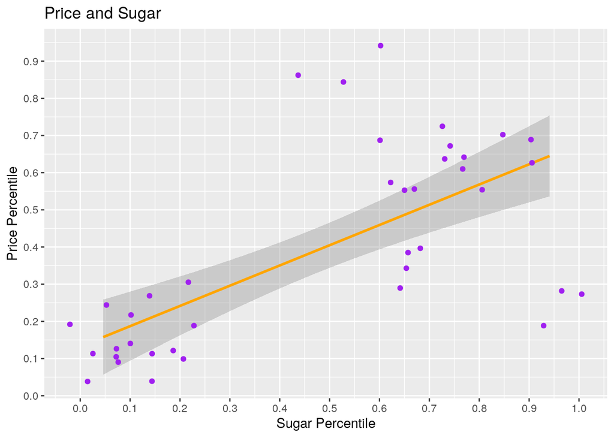

```r
joined_candy %>% ggplot(aes(x = sugarpercent, y = pricepercent)) +
    geom_smooth(method = "lm", color = "Orange") + geom_point(position = position_jitter(width = 0.1,
    height = 0.1), color = "Purple") + scale_y_continuous(breaks = seq(0,
    1, 0.1)) + scale_x_continuous(breaks = seq(0, 1, 0.1)) +
    ggtitle("Price and Sugar") + xlab("Sugar Percentile") + ylab("Price Percentile")
```

This scatterplot itself has points which display the relationship between the sugar percentile a certain Halloween candy is in to the candy’s price percentile. This plot also has a regression line so that the relationship between these two variables can be seen more clearly. As seen in this plot, it appears that there is a positive correlation between sugar percentile and price percentile. This means that as a candy has more sugar relative to the other candies, then its price goes up relative to the other candies, on average.

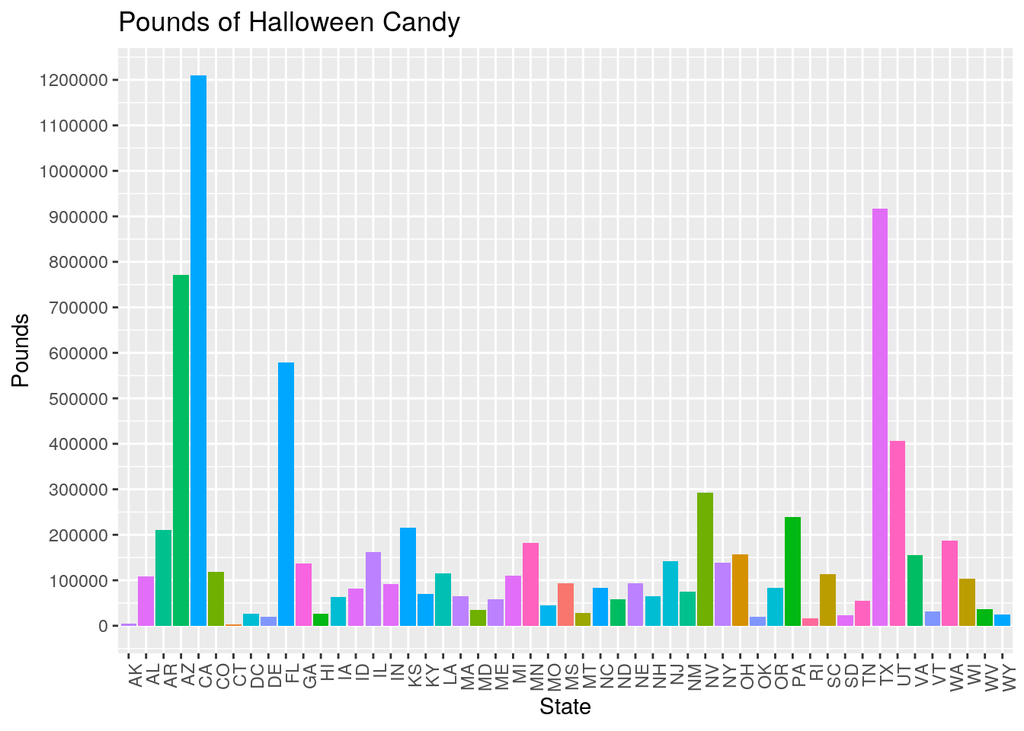

```r
joined_candy %>% ggplot(aes(x = State, fill = competitorname)) +
    geom_bar(aes(y = Pounds), stat = "summary", fun = mean) +
    theme(legend.position = "none", axis.text.x = element_text(angle = 90,
        hjust = 1)) + scale_y_continuous(breaks = seq(0, 1e+07,
    1e+05)) + ggtitle("Pounds of Halloween Candy") + xlab("State")
```

This plot clearly displays the relationship between state and the number of pounds of the state’s favorite Halloween candy that have been bought. Through this plot it is apparent that California and Texas purchased the most, while Alaska and Connecticut purchased the least. This is probably due to population differences, how much the different states celebrate Halloween, and possibly candy availability.

#### Concluding Remarks

Overall, this project allowed me to analyze the different consumer behaviors for Halloween candies throughout the United States, and how different types of candies can alter their popularity, amount of sugar, and their price. These relationships were able to be closely examined by using various wrangling, tidying, joining, and visualization strategies as shown throughout this project.